# Multi Armed Bandit

Multi-Armed Bandit 문제를 Thompson Sampling과 UCB1 알고리즘을 활용하여 풀어보고 비교해보는 예제입니다.

## 환경 설정

먼저 예제에서 사용하는 dplyr, ggplot2, foreach, doParallel, devtools, parallel 패키지를 로딩합니다.

이후 MAB에서 사용하는 환경값들을 정의해줍니다. 모형은 베르누이 bandit이며, n은 슬롯머신의 개수를, e는 머신들의 실제 확률값을 배정할 때 0.5와 0.5-e 만큼을 배정하게 되는데 이 값을 얼마로 정할지를, prob는 e와 n을 활용하여 머신들의 실제 확률값을 정한 것이며 t는 얼마나 시도할 수 있을지, cumulative_prob는 매 시도마다 머신들의 성공횟수와 총 횟수를 저장하는 데이터프레임입니다.

마지막으로 예제에 사용할 함수들을 불러옵니다.

```r
# install.packages(c('dplyr','ggplot2','foreach','doParallel','devtools', 'parallel'))
#Load package
sapply(c('dplyr','ggplot2','foreach','doParallel','devtools', 'parallel'), require, character.only = T)
```

```
##      dplyr    ggplot2    foreach doParallel   devtools   parallel
##       TRUE       TRUE       TRUE       TRUE       TRUE       TRUE
```

```r
#Set default environment for bandit problem
n = 10 #number of mach
e = 0.1
prob = c(0.5,rep(0.5-e,n-1)) #success probability of each machine : solver don't know
t = 10^2 #number of trial
cumulative_prob = data.frame(s = rep(0,n),n = rep(0,n)) # history dataframe for each trial
# s : number of success, n : number of trial

 my_locale <- Sys.getlocale("LC_ALL")
 Sys.setlocale("LC_ALL", my_locale)
```

```
## [1] ""
```

## 함수 소개

### explore_k

UCB1에서 k번 탐험을 하게 하는 기능을 하게 됩니다. 해당 결과값을(성공횟수, 총 횟수)을 df인풋(=cumulative_prob)에 업데이트 하여 결과값으로 return하게 됩니다.

```r
# force exploration by k times
explore_k = function(df,k){
  if(k == 1){
    uni_first = sapply(prob,function(x){sample(0:1,k,prob = c(1-x,x),replace = T)})
  }else{
    uni_first = sapply(prob,function(x){sample(0:1,k,prob = c(1-x,x),replace = T)}) %>% colSums
  }
  df %>%
    mutate(s = s+uni_first,n = n+k) %>% # update s and n
    mutate(prob = s/n) #make probability variable
}
```

### ucb1_iter

위의 탐험 후 iteration을 t번 실행하는 함수입니다. 주의할 점은 앞에 모든 머신을 k번 탐험하기 때문에, 실제 총 시도 횟수는 이 함수에서 넣은 t에 k*n번을 더해야 한다는 것입니다.  
로직은 단순하게 $UCB1_{i}=x_{i} + \sqrt{\frac{2ln t}{n_{i}}}$를 계산한 후 입실론-그리디 방법에 의해서 UCB1값을 최대로 하는 행동을 하되 입실론 만큼 랜덤 행동을 하게 됩니다.  
이 때 매 iteration마다 explor_df, 즉 앞서 설명한 함수 explore_k에서 나온 결과물을 새로 나온 값으로 업데이트 하게 됩니다.

```r
ucb1_iter = function(explor_df,t){ # input : explored dataframe, number of exploitation

  regret = 0

  for(i in 1:t){
    #calculate ucb1 score
    ucb1_score = explor_df$prob + sqrt(2*log(sum(explor_df$n)) / explor_df$n)

    #choose one from maximum score based on epsilon-greedy
    max_score = ifelse(sample(c(F,T),1,prob = c(epsilon,1-epsilon)), # epsilon greedy check
                       which(ucb1_score==max(ucb1_score)) %>% sample(1), # choose one of maximum
                       sample(1:nrow(explor_df),1)) # random sample

    #do trial
    max_try = sample(0:1,1,prob = c(1-prob[max_score],prob[max_score]))

    #update regret
    regret = regret + max(explor_df$prob) - explor_df[max_score,'prob']

    #update dataframe
    explor_df[max_score,'s'] = explor_df[max_score,'s']+max_try
    explor_df[max_score,'n'] = explor_df[max_score,'n']+1
    explor_df[max_score,'prob'] = explor_df[max_score,'s'] / explor_df[max_score,'n']



  }

  cat('UCB1 iteration is done \n','Trial : ',t,'\n')
  return(
    list(df = explor_df %>% mutate(prob = s/n),
         regret = regret)
  )
}
```

### Thompson

톰슨 샘플링 함수도 위와 비슷한 구조로 되어있으나, 다른 점은 매 100번째 iteration마다 beta분포 업데이트를 한 후 해당 분포에서 랜덤하게 샘플링된 값들을 입실론-그리디 방법을 통해 선택하는 것입니다.

```r
#thompson sampling method
thompson = function(df,t,a,b){

  df = df %>% mutate(prob = ifelse(n==0,0,s/n))
  regret = 0

  for(i in 1:t){

    if((i %% 100)==0){ #for every 100 iteration, update parameter
      #update alpha by sucess, beta by failure
      a = a+df$s
      b = b+(df$n-df$s)
    }

    #calculate theta(prior in beta distribution)
    theta = rbeta(nrow(df),a,b)

    #choose 1 of max theta
    choice = ifelse(sample(c(F,T),1,prob = c(epsilon,1-epsilon)), # epsilon greedy check
                    which(theta == max(theta)) %>% sample(1), # choose one of maximum
                    sample(1:nrow(df),1)) #random sample

    #do trial
    res = sample(0:1,1,prob = c(1-prob[choice],prob[choice]))

    #update regret
    regret = regret + max(df$prob) - df[choice,'prob']


    #update dataframe
    df[choice,'s'] = df[choice,'s'] + res
    df[choice,'n'] = df[choice,'n'] + 1
    df[choice,'prob'] = df[choice,'s'] / df[choice,'n']
  }

  cat('Thompson sampling iteration is done \n','Trial : ',t,'\n')
  return(
    list(df = df %>% mutate(prob = ifelse(n==0,0,s/n)),
         regret = regret)

  )
}
```

### perform_check

UCB1과 thompson sampling을 비교할때 여러 trial 횟수를 병렬처리해주는 함수입니다. df는 cumulative_prob를, 나머지 셋은 총 시도횟수를 어떤 범위만큼 테스트 할지를 정하는 데 사용합니다. 주의할 점은 함수 내부의 performance_check를 만드는 foreach문이 글로벌 환경에 있는 객체들을 가져다 쓰기 때문에, .export에 있는 값들이 글로벌 환경에 선언되어있지 않다면 에러가 생길 수 있습니다.

```r
#Compre performance of UCB and Thompson
perform_check = function(df,min,max,interval){

  #Check performance by min~max and plot it

  #create range by given input
  r = seq(min,max,interval)

  #register cluster and do parallel loop
  cl = makeCluster(detectCores()-1)
  registerDoParallel(cl)

  performance_check = foreach(x = r,.combine = rbind,
                              .packages = 'dplyr',
                              .export = c('explore_k','prob','cumulative_prob','ucb1_iter',
                                          'thompson','alpha','beta','epsilon','n')) %dopar% {

                                            ucb1 = (explore_k(cumulative_prob,1) %>% ucb1_iter(x-n))
                                            thomp = thompson(cumulative_prob,x,alpha,beta)

                                            data.frame(
                                              trial = x,
                                              ucb1_reward = sum(ucb1$df$s),
                                              ucb1_regret = ucb1$regret,
                                              thompson_reward = sum(thomp$df$s),
                                              thompson_regret = thomp$regret
                                            )

                                          }

  stopCluster(cl)
  return(list(
    # Reward plot
    reward_plot = data.frame(t = rep(r,2),
                             reward = c(performance_check$ucb1_reward,
                                        performance_check$thompson_reward),
                             method = c(rep('ucb1',nrow(performance_check)),
                                        rep('thompson',nrow(performance_check)))) %>%
      ggplot(aes(t,reward,color = method))+
      geom_point(alpha = 0.2)+
      geom_smooth(size = 1.5,se = F)+
      ggtitle('Thompson sampling vs UCB1 : Reward',
              subtitle = paste0('t = {', min, ' ~ ', max, '} | ','n = ',n,' | e = ',e))+
      theme_bw(),

    # Data
    data = performance_check,

    # Regret plot
    regret_plot = data.frame(t = rep(r,2),
                             regret = c(performance_check$ucb1_regret,
                                        performance_check$thompson_regret),
                             method = c(rep('ucb1',nrow(performance_check)),
                                        rep('thompson',nrow(performance_check)))) %>%
      ggplot(aes(t,regret,color = method))+
      geom_point(alpha = 0.2)+
      geom_smooth(size = 1.5,se = F)+
      ggtitle('Thompson sampling vs UCB1 : Regret',
              subtitle = paste0('t = {', min, ' ~ ', max, '} | ','n = ',n,' | e = ',e))+
      theme_bw(),

    #Success rate plot
    srate_plot = data.frame(t = rep(r,2),
                            reward = c(performance_check$ucb1_reward,
                                       performance_check$thompson_reward),
                            method = c(rep('ucb1',nrow(performance_check)),
                                       rep('thompson',nrow(performance_check)))) %>%
      ggplot(aes(t,reward/t,color = method))+
      geom_point(alpha = 0.2)+
      geom_smooth(size = 1.5,se = F)+
      ggtitle('Thompson sampling vs UCB1 : Success rate',
              subtitle = paste0('t = {', min, ' ~ ', max, '} | ','n = ',n,' | e = ',e))+
      ylab('Success rate')+
      theme_bw()


  ))

}
```

## 개별 모델 TEST

### UCB1(Upper Confidence Bound 1)

```r
# epsilon - greedy as base
epsilon = 0.01

# Exploration - k try for all mach
k = 1 # number of exploration

ucb1_res = explore_k(cumulative_prob,k) %>% ucb1_iter(t-n)  #result
```

```
## UCB1 iteration is done
##  Trial :  90
```

iteration이 끝나면 메세지가 출력되며, 결과는 다음과 같이 나오게 됩니다. df는 누적 성공 및 총 횟수와 두 값을 나눈 값(prob = s/n)을, regret은 regret function으로 나온 값의 누적값을 의미합니다.

```r
ucb1_res$df
```

```
##    s  n      prob
## 1  5 12 0.4166667
## 2  4 12 0.3333333
## 3  5 13 0.3846154
## 4  7 11 0.6363636
## 5  5 12 0.4166667
## 6  6 13 0.4615385
## 7  1  8 0.1250000
## 8  3  9 0.3333333
## 9  2  6 0.3333333
## 10 2  4 0.5000000
```

```r
ucb1_res$regret
```

```
## [1] 29.2952
```

### Thompson sampling

톰슨 샘플링은 Randomized bayesian bandit 모형으로, 해당 예제에서는 계산속도를 위해 매 100번 iteration마다 beta 분포를 업데이트 하도록 지정해두었습니다. 두 파라미터 alpha와 beta는 각각 베타분포의 첫번째, 두번째 항에 대한 초기값입니다.

```r
#parameter for prior beta distribution
alpha = 1
beta = 1

thompson_res = thompson(cumulative_prob,t,alpha,beta)
```

```
## Thompson sampling iteration is done
##  Trial :  100
```

위와 마찬가지로 결과는 두 개의 요소를 지닌 list 형식으로 출력됩니다.

```r
thompson_res$df
```

```
##     s  n      prob
## 1  11 28 0.3928571
## 2   6 22 0.2727273
## 3   4  9 0.4444444
## 4   4 11 0.3636364
## 5   2  8 0.2500000
## 6   4  6 0.6666667
## 7   2  5 0.4000000
## 8   2  8 0.2500000
## 9   1  2 0.5000000
## 10  0  1 0.0000000
```

```r
thompson_res$regret
```

```
## [1] 51.06083
```

### UCB1 VS Thompson

```r
#by total total reward
ifelse((sum(ucb1_res$s) > sum(thompson_res$s)),
       paste0('UCB1 is better : ',t,' trial'),
       paste0('Thompson is better : ',t,' trial'))
```

```
## [1] "Thompson is better : 100 trial"
```

하지만 이는 랜덤행동의 영향이 큰 적은 횟수의 시도이기 때문에, 정확한 비교를 위해 100부터 10,000번까지 시도를 두 모델을 가지고 하도록 하겠습니다. 이 때 병렬처리 및 결과 시각화를 위해 perform_check라는 함수를 쓰게 됩니다.

```r
#performance check function
res = perform_check(cumulative_prob,10^2,10^4,100)
```

결과는 4개로 reward, regret, srate(성공률) plot 3개와 각 시도 별 총 보상(reward)과 regret이 어떻게 되었는지 저장한 data 객체가 있습니다.

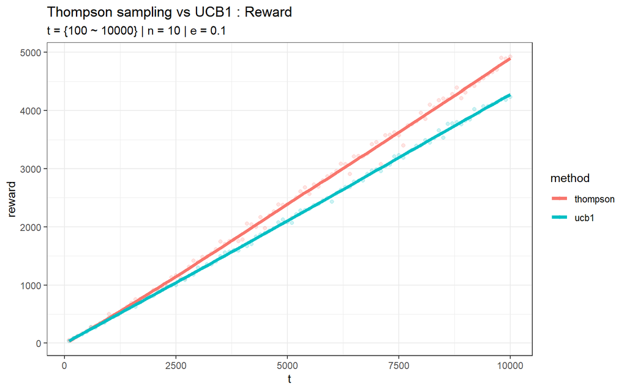

```r
res$reward_plot
```

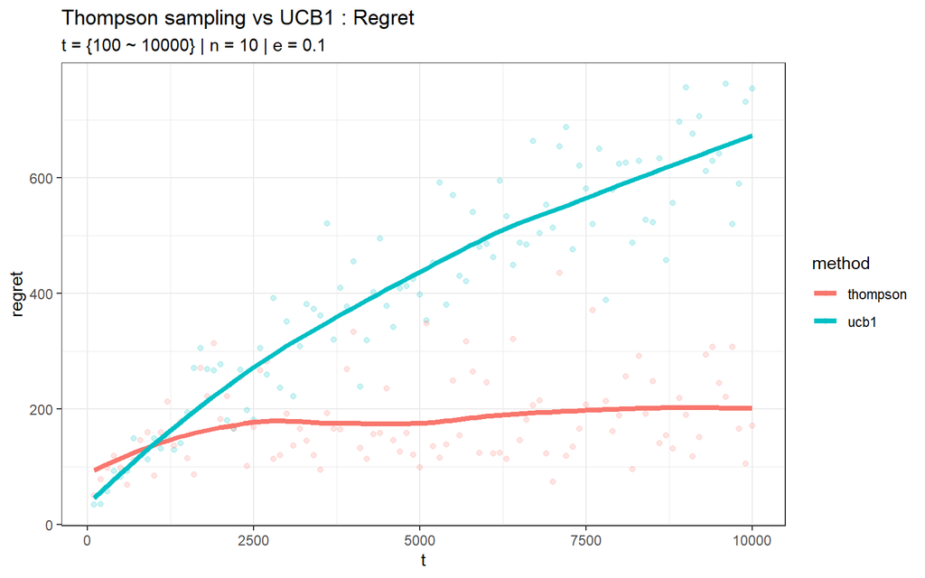

```r
res$regret_plot
```

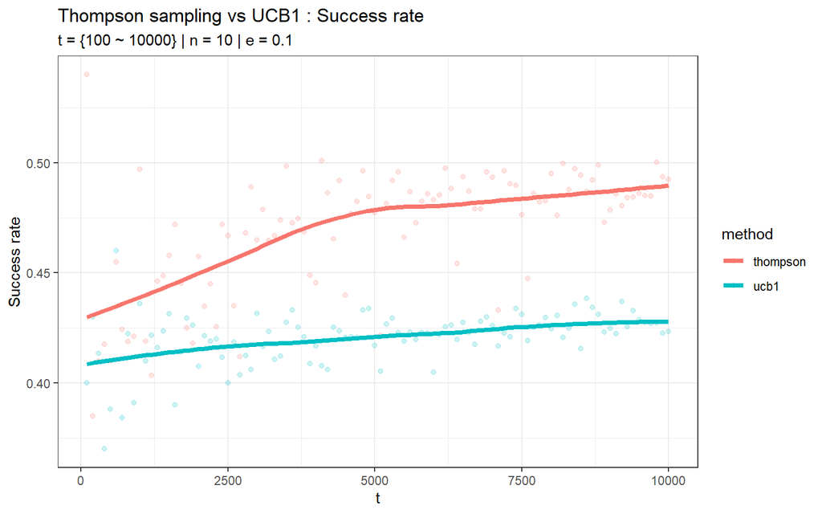

```r
res$srate_plot
```